# MATH 3070 Lab Project 13

Kanishka Ragula

30 November, 2017

*Remember: I expect to see commentary either in the text, in the code with comments created using `#`, or (preferably) both! **Failing to do so may result in lost points!***

## Problem 1 (Verzani problem 9.14)

*The data set `normtemp` (**UsingR**) contains measurements of 130 healthy, randomly selected individuals. The variable `temperature` contains normal body temperature. Does the data appear to come from a Normal distribution? If so, perform a $t$-test to see if the commonly assumed value of 98.6 degrees fahrenheit is correct. (Studies have suggested that 98.2 degrees fahrenheit is more accurate.)*

```r
library(UsingR)
for (i in 1:100) {
    print("HI CHANEL!")
}
```

[output not shown]

[output cut: 85 more lines]

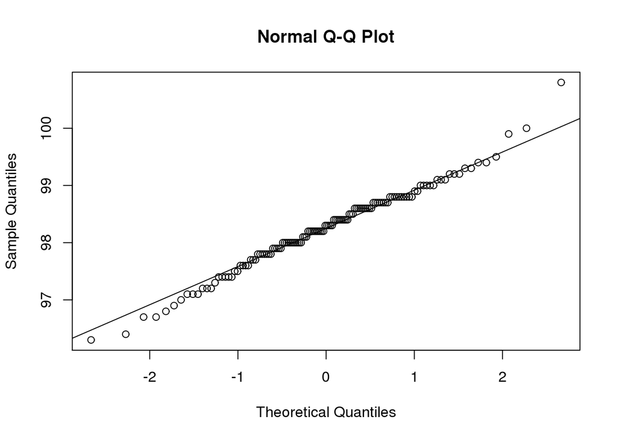

```r
qqnorm(normtemp$temperature)  #QQ Plot for the data
qqline(normtemp$temperature)
```

```r
# This appears to follow a normal distribution so it is appropriate to
# follow a t-test.

t.test(normtemp$temperature, conf.level = 0.99)
```

```
##
##  One Sample t-test
##
## data:  normtemp$temperature
## t = 1527.9, df = 129, p-value < 2.2e-16
## alternative hypothesis: true mean is not equal to 0
## 99 percent confidence interval:
##  98.08111 98.41735
## sample estimates:
## mean of x
##  98.24923
```

```r
# We can say with a 99% confidence that 98.6 is not correct.
```

## Problem 2 (Verzani problem 9.4)

*In the United States in 2007, the proportion of adults age 21-24 who had no medical insurance was 28.1 percent. A survey of 75 recent college graduates in this age range finds that 40 percent are without insurance. Does this support a difference from the nationwide proportion? Perform a test of significance and report the p-value. Is it significant? (Perform this test “by hand”, not using `prop.test()`.)*

```r
perc = 0.4
nullH = 0.281
z = ((perc - nullH)/(sqrt((nullH * (1 - nullH))/75)))  #Run the proportion test
pval = 2 * (1 - pnorm(abs(z)))
print(pval)
```

```
## [1] 0.0218614
```

```r
# This is less than .05 so it is significant.
```

## Problem 3 (Verzani problem 9.16)

*A one-sided, one-sample $t$-test will be performed. What sample size is needed to have a power of 0.80 for a significance level of 0.05 if `delta = 0.05` and the population standard deviation is assumed to be 5?*

```r
power.t.test(n = 61827, delta = 0.05, sd = 5, sig.level = 0.05, type = "paired",
    alternative = "one.sided")
```

```
##
##      Paired t test power calculation
##
##               n = 61827
##           delta = 0.05
##              sd = 5
##       sig.level = 0.05
##           power = 0.8000004
##     alternative = one.sided
##
## NOTE: n is number of *pairs*, sd is std.dev. of *differences* within pairs
```

```r
# You need 61827 sample size to have a power of .80
```